# Post-Washout JAK3 Regulation Across Human Macrophage Training Models

Cross-dataset evidence synthesis of persistent JAK3 regulation

Published

October 16, 2026

## 1 Executive summary

This report consolidates **21 stimulus comparisons from 12 datasets** to assess whether JAK3 expression changes persist after stimulus withdrawal in human monocyte/macrophage systems. **Six comparisons from four datasets** show FDR-supported positive JAK3 regulation. Evidence varies across stimuli and experiments, and these counts do not represent 21 independent studies.

In the donor-adjusted **GSE168468** analysis, resting Day 6 JAK3 is elevated after LPS and both BCG conditions relative to RPMI. Direct BCG-versus-LPS tests do not detect a JAK3 difference, but their confidence intervals do not establish equivalence. A comparison with HCK, LYN, IRAK2 and EPHB2 shows that EPHB2 has FDR-supported BCG-versus-LPS contrasts, whereas JAK3 does not.

## 2 Research questions and methods

The synthesis addresses: (1) reproducibility across training contexts; (2) effect precision; (3) direct stimulus differences; and (4) whether JAK3’s pattern is distinctive within a five-gene comparator panel.

Existing coefficients and confidence intervals were harmonized to **log2 units**. MMSEQ natural-log effects were divided by ln(2); DESeq2, RMA-log2, and voom-log2 effects were retained. P values and FDR were not altered by the scale conversion. Confidence intervals refer to individual contrasts; they are **not multiplicity-adjusted simultaneous intervals**. Different source analyses used different designs and uncertainty estimators.

For GSE58310, reported P values come from **gene-specific paired t-tests** and no genome-wide FDR is available. The GSE235094 monocyte-only experiment is supportive but not independent macrophage validation. Multiple conditions within one dataset are not independent replication datasets.

## 3 Where does post-washout JAK3 regulation reproduce?

JAK3 contrasts with genome-wide FDR < 0.05

|  | Dataset | Stimulus | Effect | CI_low | CI_high | FDR |
| --- | --- | --- | --- | --- | --- | --- |
| 3 | GSE168468 | LPS | 2.499 | 1.777 | 3.221 | 0.013 |
| 4 | GSE168468 | BCG Denmark | 2.527 | 1.805 | 3.248 | 0.003 |
| 5 | GSE168468 | BCG Bulgaria | 2.660 | 1.938 | 3.382 | 0.001 |
| 6 | GSE262098 | BCG | 2.365 | 1.351 | 3.379 | 0.002 |
| 15 | GSE242947 | Zymosan | 2.582 | 1.513 | 3.652 | 0.002 |
| 21 | E-MTAB-9214 | House_dust_mite | 1.700 | 1.155 | 2.246 | 0.000 |

Positive FDR-supported effects occur for LPS and BCG in GSE168468, BCG in GSE262098, zymosan in GSE242947, and house dust mite (HDM) in E-MTAB-9214. These six contrasts are from **four datasets**. Other effects are heterogeneous or not statistically supported; nonsignificance is not evidence of no biological effect.

GSE58310 beta-glucan shows a consistent negative JAK3 shift in four donor pairs (paired t-test P = 0.0193), but its Wilcoxon P = 0.1003 and genome-wide FDR is unavailable. This is **nominal**, not FDR-supported, evidence.

### 3.1 Full evidence table

All 21 harmonized JAK3 contrasts

| Dataset | Stimulus | Timepoint | log2 effect | CI lower | CI upper | FDR |
| --- | --- | --- | --- | --- | --- | --- |
| GSE58310 | LPS | Day6 | 1.036 | -1.298 | 3.371 | NA |
| GSE58310 | Beta-glucan | Day6 | -1.009 | -1.707 | -0.312 | NA |
| GSE168468 | LPS | Day6 | 2.499 | 1.777 | 3.221 | 0.013 |
| GSE168468 | BCG Denmark | Day6 | 2.527 | 1.805 | 3.248 | 0.003 |
| GSE168468 | BCG Bulgaria | Day6 | 2.660 | 1.938 | 3.382 | 0.001 |
| GSE262098 | BCG | Day6 | 2.365 | 1.351 | 3.379 | 0.002 |
| GSE166238 | oxLDL | Day6 | -0.323 | -2.275 | 1.629 | 1.000 |
| GSE235897 | MMA | Day6 | 0.055 | -2.516 | 2.626 | 1.000 |
| GSE121696 | Aldosterone | Day6 | -0.075 | -0.573 | 0.423 | 0.999 |
| GSE141656 | Beta-glucan | Day6 | -0.151 | -2.308 | 2.005 | 0.940 |
| GSE212282 | Beta-glucan | Day6 | 0.669 | -0.353 | 1.691 | 0.527 |
| GSE212282 | DMI | Day6 | 0.052 | -0.971 | 1.075 | 0.997 |
| GSE212282 | Itaconate | Day6 | 0.793 | -0.228 | 1.816 | 0.805 |
| GSE212282 | BG+DMI | Day6 | 0.163 | -0.860 | 1.186 | 0.915 |
| GSE242947 | Zymosan | Day7_0h | 2.582 | 1.513 | 3.652 | 0.002 |
| GSE242947 | ETSU_beta-glucan | Day7_0h | 1.278 | 0.204 | 2.352 | 1.000 |
| GSE242947 | Depleted_zymosan | Day7_0h | 1.202 | 0.124 | 2.280 | 0.422 |
| GSE110947 | Heme | Day6 | -0.729 | -1.633 | 0.175 | 0.359 |
| GSE110947 | Beta-glucan | Day6 | 0.065 | -0.840 | 0.968 | 0.967 |
| GSE235094 | iSARS-CoV-2 | Day6 | -1.709 | -3.249 | -0.169 | 0.144 |
| E-MTAB-9214 | House_dust_mite | D7HDM (resting) | 1.700 | 1.155 | 2.246 | 0.000 |

## 4 How precisely are effects estimated?

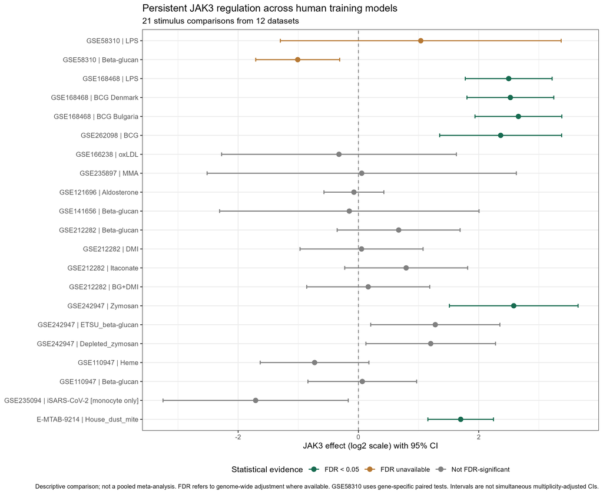

Cross-dataset JAK3 forest plot. The plot is descriptive, not a pooled meta-analysis.

The forest plot displays effects and corresponding 95% CIs on the log2 scale. FDR significance is based on genome-wide adjustment where available. GSE58310 has gene-specific paired-test evidence only. The small sample sizes of some studies and differences in methods constrain generalization.

## 5 Are BCG and LPS effects directly different?

In GSE168468, a donor-adjusted model estimates resting Day 6 effects before secondary challenge.

### 5.1 Each training condition versus RPMI

Day 6 JAK3 training effects versus RPMI

| Contrast | log2FC | CI_low | CI_high | FDR |
| --- | --- | --- | --- | --- |
| Day6_LPS_vs_RPMI | 2.499 | 1.777 | 3.221 | 0.013 |
| Day6_BCG_Denmark_vs_RPMI | 2.527 | 1.805 | 3.248 | 0.003 |
| Day6_BCG_Bulgaria_vs_RPMI | 2.660 | 1.938 | 3.382 | 0.001 |

### 5.2 Direct stimulus comparisons

Direct BCG/LPS contrasts; converted to log2 units

| Contrast | log2FC | CI_low | CI_high | FDR |
| --- | --- | --- | --- | --- |
| Denmark_vs_LPS | 0.028 | -0.694 | 0.750 | 0.978 |
| Bulgaria_vs_LPS | 0.162 | -0.560 | 0.883 | 0.851 |
| BCG_average_vs_LPS | 0.095 | -0.530 | 0.720 | 0.893 |
| Denmark_vs_Bulgaria | -0.134 | -0.856 | 0.588 | 1.000 |

All three training-versus-RPMI JAK3 contrasts are FDR-supported and positive. None of the direct BCG-versus-LPS JAK3 contrasts is FDR-significant. The result indicates **no difference detected at available precision**, not equivalence.

## 6 Is the JAK3 pattern distinctive?

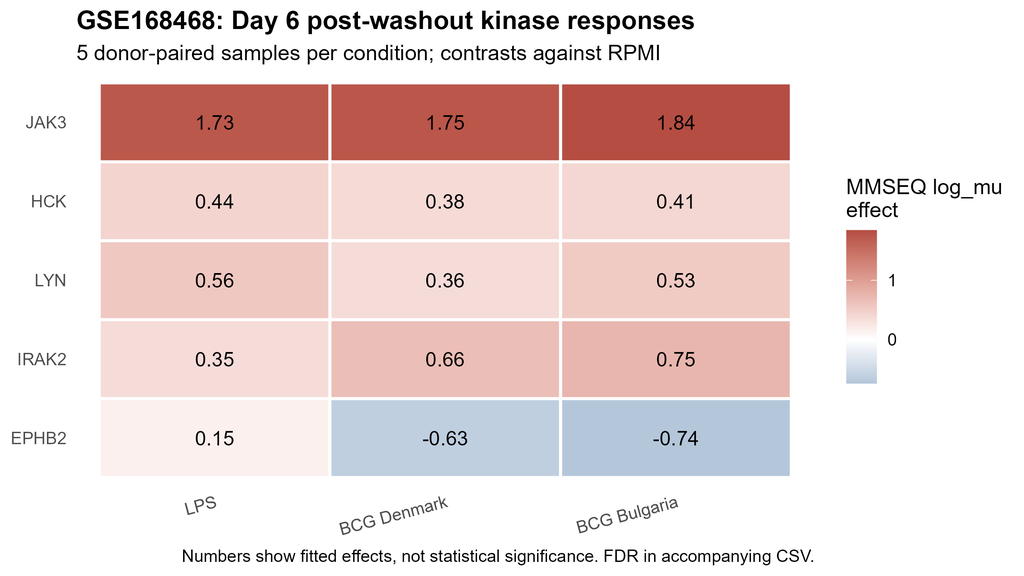

Five-gene effect heatmap. Note: the original heatmap labels MMSEQ natural-log effects; numerical tables below use log2 units.

### 6.1 Responses relative to RPMI

Five-gene training effects versus RPMI

| Gene | Contrast | log2FC | FDR |
| --- | --- | --- | --- |
| HCK | Day6_LPS_vs_RPMI | 0.628 | 0.189 |
| JAK3 | Day6_LPS_vs_RPMI | 2.499 | 0.013 |
| EPHB2 | Day6_LPS_vs_RPMI | 0.220 | 0.650 |
| IRAK2 | Day6_LPS_vs_RPMI | 0.510 | 0.172 |
| LYN | Day6_LPS_vs_RPMI | 0.815 | 0.050 |
| HCK | Day6_BCG_Denmark_vs_RPMI | 0.542 | 0.288 |
| JAK3 | Day6_BCG_Denmark_vs_RPMI | 2.527 | 0.003 |
| EPHB2 | Day6_BCG_Denmark_vs_RPMI | -0.903 | 0.054 |
| IRAK2 | Day6_BCG_Denmark_vs_RPMI | 0.954 | 0.017 |
| LYN | Day6_BCG_Denmark_vs_RPMI | 0.514 | 0.185 |
| HCK | Day6_BCG_Bulgaria_vs_RPMI | 0.590 | 0.199 |
| JAK3 | Day6_BCG_Bulgaria_vs_RPMI | 2.660 | 0.001 |
| EPHB2 | Day6_BCG_Bulgaria_vs_RPMI | -1.067 | 0.016 |
| IRAK2 | Day6_BCG_Bulgaria_vs_RPMI | 1.079 | 0.005 |
| LYN | Day6_BCG_Bulgaria_vs_RPMI | 0.768 | 0.030 |

### 6.2 Direct BCG-versus-LPS responses

Direct contrasts for five comparator genes

| Gene | Contrast | log2FC | FDR |
| --- | --- | --- | --- |
| HCK | Denmark_vs_LPS | -0.086 | 0.888 |
| JAK3 | Denmark_vs_LPS | 0.028 | 0.978 |
| EPHB2 | Denmark_vs_LPS | -1.123 | 0.026 |
| IRAK2 | Denmark_vs_LPS | 0.444 | 0.217 |
| LYN | Denmark_vs_LPS | -0.300 | 0.425 |
| HCK | Bulgaria_vs_LPS | -0.038 | 0.953 |
| JAK3 | Bulgaria_vs_LPS | 0.162 | 0.851 |
| EPHB2 | Bulgaria_vs_LPS | -1.288 | 0.014 |
| IRAK2 | Bulgaria_vs_LPS | 0.569 | 0.118 |
| LYN | Bulgaria_vs_LPS | -0.047 | 0.926 |

JAK3 is upregulated in all three training conditions. IRAK2 also shows FDR-supported positive regulation after BCG, indicating that JAK3 is not the only responsive signaling gene. EPHB2 has **FDR-supported negative BCG-versus-LPS contrasts**, unlike JAK3. This is evidence of different *observed patterns*, not a formal gene-by-gene interaction test.

## 7 Limitations

- Experimental protocols, donors, cell-state definitions and analysis models differ across datasets; differences cannot be attributed to stimulus alone.
- Twenty-one comparisons arise from 12 datasets and are not independent biological replications.
- Some reported intervals are approximate Wald intervals; none is a simultaneous multiple-comparison-adjusted CI.
- GSE58310 has no genome-wide FDR and its nominal negative beta-glucan result requires caution.
- GSE235094 is a monocyte-only supporting model rather than independent resting-macrophage validation.
- The deposited HDM label is D7HDM; its exact days since washout should not be inferred from the label alone.
- This figure is a **descriptive forest plot**, not a pooled effect estimate or meta-analysis.

## 8 Conclusions

**Reproducibility:** Positive post-washout JAK3 regulation has independent support in several models, but is not universal.

**Precision:** The harmonized table reports effect sizes, 95% confidence intervals and genome-wide FDR where available, while retaining study-specific limitations.

**Stimulus dependence:** GSE168468 provides no direct statistical evidence for a JAK3 difference between BCG and LPS at Day 6; this does not prove equivalence.

**Comparator panel:** JAK3 participates in a broader response, while EPHB2 shows direct stimulus-dependent contrasts in this panel. A formal cross-gene test would be needed to compare stimulus sensitivity between genes.